# Part 2: Data Analysis

Briantama Asmara

12/10/2021

# Part 2: Data Analysis

## Data Exploration

### Loading Packages

- Load here() packages

```r
require(here)
here()
```

```
## [1] "D:/UMass/OneDrive - University of Massachusetts/Documents/env_data"
```

### Numerical Exploration

- Load data

```r
delomys = data.frame(read.csv(here("data", "delomys.csv")))
```

- Check data

```r
head(delomys)
```

```
##       X   genus         binomial body_mass body_length   age    sex longitude
## 1 27526 Delomys Delomys dorsalis      50.5         259 adult female -48.22950
## 2 27528 Delomys Delomys dorsalis      79.0         223 adult female -48.22950
## 3 27529 Delomys Delomys dorsalis      57.0         206 adult female -48.22950
## 4 27530 Delomys Delomys dorsalis      71.0         229 adult   male -48.22950
## 5 27533 Delomys Delomys dorsalis      56.0         105 adult   male -50.39215
## 6 27534 Delomys Delomys dorsalis      50.0         118 adult   male -50.39215
##    latitude status
## 1 -24.20256  alive
## 2 -24.20256  alive
## 3 -24.20256  alive
## 4 -24.20256  alive
## 5 -29.40807  alive
## 6 -29.40807   dead
```

- Summary of the body mass and body length data of Delomys

```r
summary(delomys$body_mass)
```

```
##    Min. 1st Qu.  Median    Mean 3rd Qu.    Max.
##    5.00   35.00   43.00   44.06   54.00  105.00
```

```r
summary(delomys$body_length)
```

```
##    Min. 1st Qu.  Median    Mean 3rd Qu.    Max.
##    49.0   106.0   116.0   114.7   124.0   265.0
```

- Normality test

```r
shapiro.test(delomys$body_mass)
```

```
##
##  Shapiro-Wilk normality test
##
## data:  delomys$body_mass
## W = 0.99506, p-value = 4.33e-05
```

```r
shapiro.test(delomys$body_length)
```

```
##
##  Shapiro-Wilk normality test
##
## data:  delomys$body_length
## W = 0.87609, p-value < 2.2e-16
```

### Graphical Exploration

- A scatterplot of body mass and body length

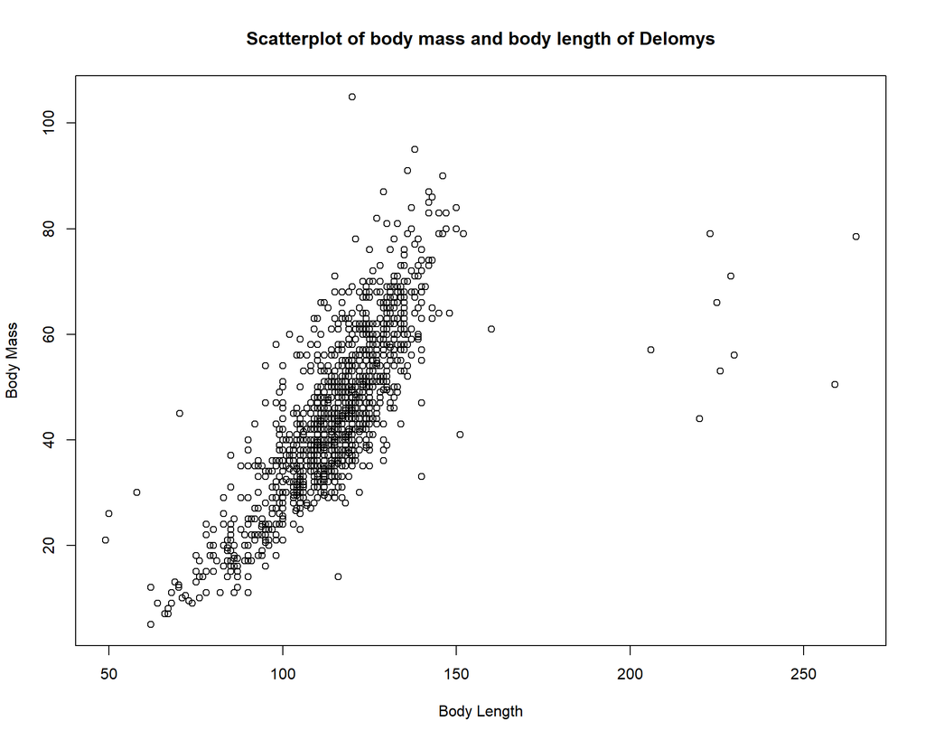

```r
plot(delomys$body_mass ~ delomys$body_length,
     main= 'Scatterplot of body mass and body length of Delomys',
     xlab='Body Length',
     ylab='Body Mass')
```

- A histogram of body mass

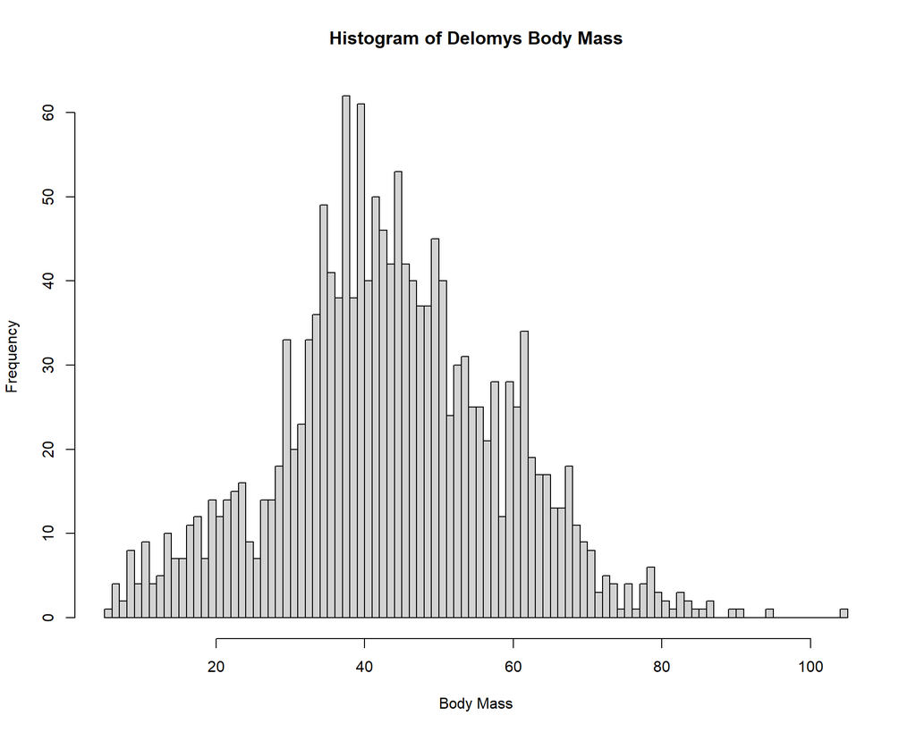

```r
hist(delomys$body_mass,
     breaks = 100,
     main="Histogram of Delomys Body Mass",
     xlab="Body Mass")
```

- A histogram of body length

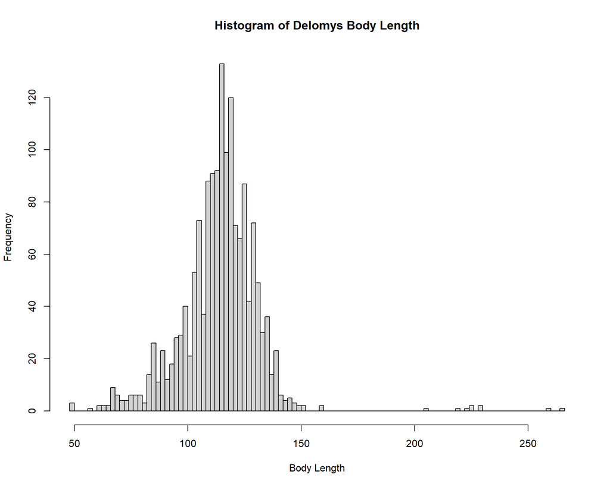

```r
hist(delomys$body_length,
     breaks = 100,
     main="Histogram of Delomys Body Length",
     xlab="Body Length")
```

- A conditional boxplot of body mass, conditioned on species (column binomial)

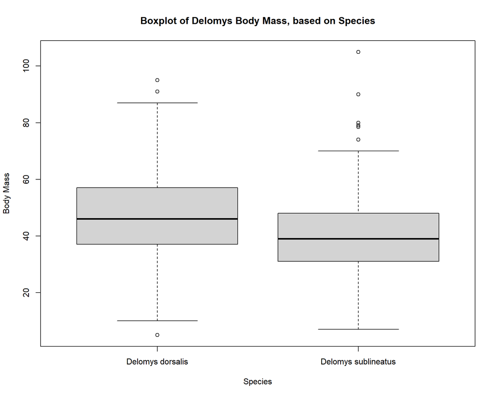

```r
boxplot(delomys$body_mass ~ delomys$binomial,
        main="Boxplot of Delomys Body Mass, based on Species",
        xlab="Species",
        ylab="Body Mass")
```

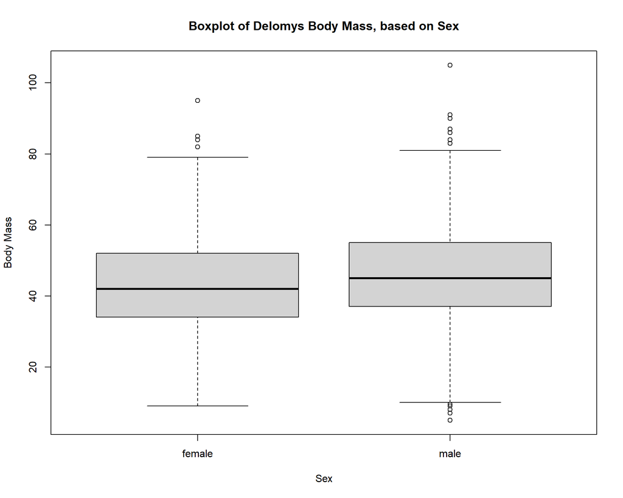

```r
boxplot(delomys$body_mass ~ delomys$sex,
        main="Boxplot of Delomys Body Mass, based on Sex",
        xlab="Sex",
        ylab="Body Mass")
```

- A conditional boxplot of body mass, conditioned on both species and sex

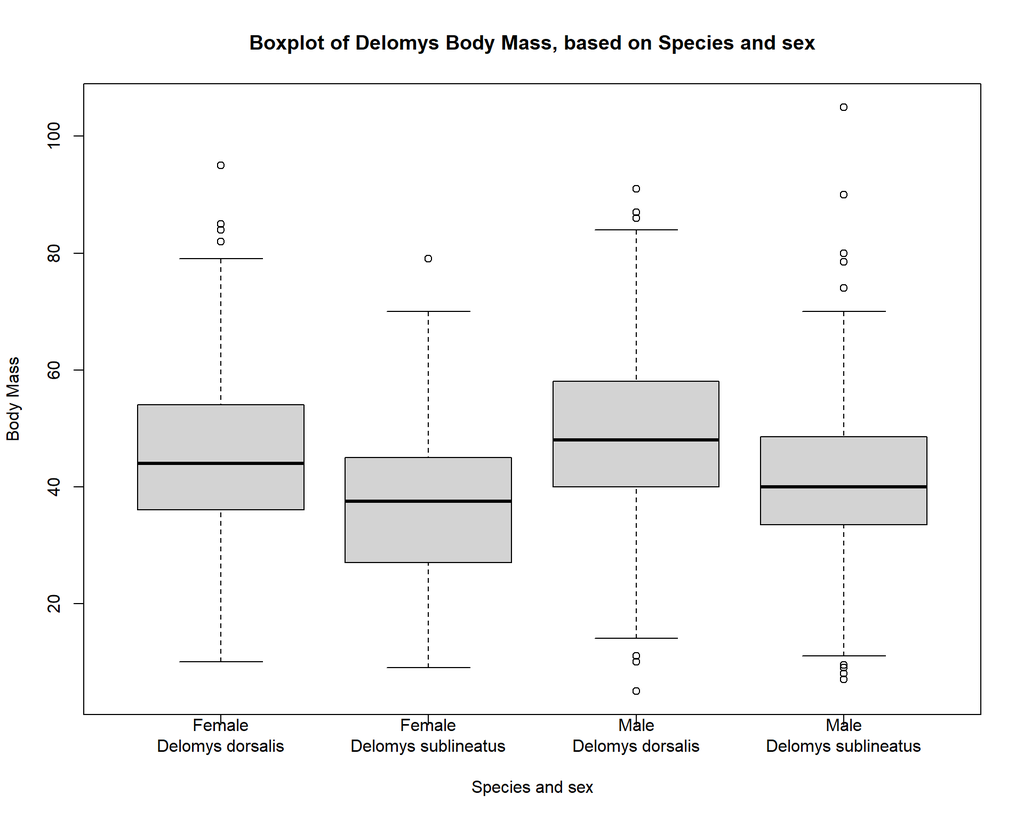

```r
boxplot(delomys$body_mass ~ delomys$binomial+delomys$sex,
        main="Boxplot of Delomys Body Mass, based on Species and sex",
        xlab="Species and sex",
        ylab="Body Mass",
        names = c("Female\nDelomys dorsalis", "Female\nDelomys sublineatus", "Male\nDelomys dorsalis", "Male\nDelomys sublineatus"))
```

### Q1-4

- Q1

Qualitatively describe the relationship between body mass and length. Does the relationship seem linear, curved, nonexistent?

The relationship shown from the scatterplot looks linear to me. Therefore, if the body length becomes larger, the same also goes for body mass. Despite there are several outliers due to high body length (>200), the relationship is linear.

- Q2

Qualitatively describe the shapes of the histograms.Do the data appear normally-distributed? Explain why or why not.

Both data (body mass and body length) appear normally-distributed because they have a bell-shaped histogram; the data tend to distribute towards the center. Despite the body mass histogram is kind of skewed towards the left and the body length have many outliers far beyond the right of distribution, qualitatively I would argue these histograms are normally-distributed.

- Q3

Using both the histograms and normality tests, do you think the (unconditioned) body masses and body length are normally-distributed?

Contrast your visual assessment of normality to the results of the numerical normality tests.

My visual assessments are rejected from the normality tests. When my initial assessments stated that both data (body masses and body length) are normally distributed, the normality tests shows otherwise. Both of them have really low p-values. It means that there is good evidence against the null-hypothesis; body masses and body length do not come from normally distributed population. I would suggest that even though it has bell-shaped distribution, it doesn’t always mean it will normally distributed. To clarify that, you also need a confirmation from statistical test, not just from visual evidences.

- Q4

Examine the conditional boxplots. Describe any graphical evidence you see for body mass differences based on species and/or sex.

Based on individual boxplots of species, it shows that median value of dorsalis is slightly larger than sublineatus. Despite being slightly lighter than dorsalis, the sublineatus has numerous outliers on the upper body mass; there are still a possibility that there is no difference between the two species.

On the sex boxplots, there is virtually no differences in terms of sex. The median value of male is slightly larger. I noticed there are many outliers on both direction (lower and upper values), meaning there is a possibility that the median could go lower (female and male are equal) or may increase the gaps from the female counterpart (male is relatively higher than the female).

Based on the boxplot of both species and sex, it is only make it obvious from each individual boxplots. We already know firsthand that the female and male of the same species nearly didn’t share any differences between them. In addition, the delomys dorsalis is slightly larger in terms of body mass compared to sublineatus.

### Model Building

We know that the normality assumption applies to the residual values after we fit a model.

- Model 1: simple linear regression body_length ~ body_mass

```r
fit1 = lm(body_length ~ body_mass, data = delomys)
```

- Model 2: 1-way ANOVA body_mass ~ sex

```r
fit2 = lm(body_mass ~ sex, data = delomys)
anova(fit2)
```

```
## Analysis of Variance Table
##
## Response: body_mass
##             Df Sum Sq Mean Sq F value    Pr(>F)
## sex          1   3062 3061.68  13.943 0.0001951 ***
## Residuals 1578 346507  219.59
## ---
## Signif. codes:  0 '***' 0.001 '**' 0.01 '*' 0.05 '.' 0.1 ' ' 1
```

- Model 3: 1-way ANOVA body_mass ~ binomial

```r
fit3 = lm(body_mass ~ binomial, data = delomys)
anova(fit3)
```

```
## Analysis of Variance Table
##
## Response: body_mass
##             Df Sum Sq Mean Sq F value    Pr(>F)
## binomial     1  21290 21289.7  102.08 < 2.2e-16 ***
## Residuals 1583 330164   208.6
## ---
## Signif. codes:  0 '***' 0.001 '**' 0.01 '*' 0.05 '.' 0.1 ' ' 1
```

- Model 4: 2-way additive ANOVA body_mass ~ sex + binomial

```r
fit4 = lm(body_mass ~ sex + binomial, data = delomys)
anova(fit4)
```

```
## Analysis of Variance Table
##
## Response: body_mass
##             Df Sum Sq Mean Sq F value    Pr(>F)
## sex          1   3062  3061.7  14.958 0.0001144 ***
## binomial     1  23727 23727.1 115.923 < 2.2e-16 ***
## Residuals 1577 322780   204.7
## ---
## Signif. codes:  0 '***' 0.001 '**' 0.01 '*' 0.05 '.' 0.1 ' ' 1
```

- Model 5: 2-way factorial ANOVA body_mass ~ sex * binomial

```r
fit5= lm(body_mass ~ sex * binomial, data = delomys)
anova(fit5)
```

```
## Analysis of Variance Table
##
## Response: body_mass
##                Df Sum Sq Mean Sq  F value    Pr(>F)
## sex             1   3062  3061.7  14.9489  0.000115 ***
## binomial        1  23727 23727.1 115.8500 < 2.2e-16 ***
## sex:binomial    1      1     0.8   0.0039  0.950442
## Residuals    1576 322779   204.8
## ---
## Signif. codes:  0 '***' 0.001 '**' 0.01 '*' 0.05 '.' 0.1 ' ' 1
```

### Model Diagnostics

Let’s check whether our models fulfill the assumption of normality of the residuals.

- Histograms of Residual

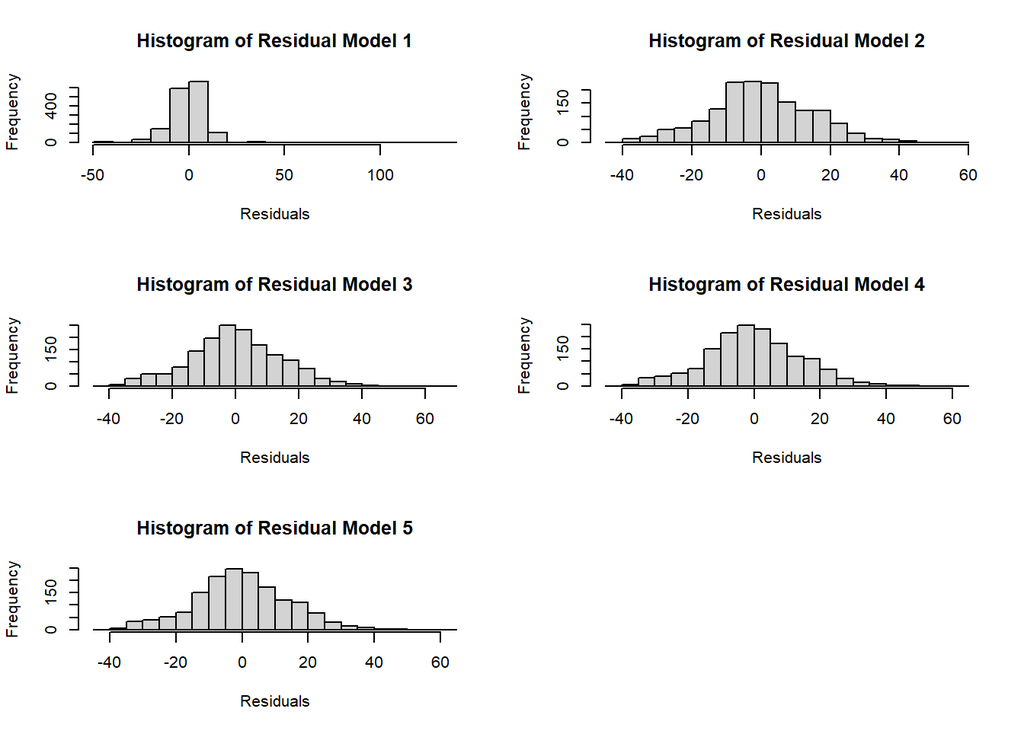

```r
par(mfrow = c(3, 2))

hist(residuals(fit1),
     breaks=20,
     main= "Histogram of Residual Model 1",
     xlab= "Residuals")
hist(residuals(fit2),
     breaks=20,
     main= "Histogram of Residual Model 2",
     xlab= "Residuals")
hist(residuals(fit3),
     breaks=20,
     main= "Histogram of Residual Model 3",
     xlab= "Residuals")
hist(residuals(fit4),
     breaks=20,
     main= "Histogram of Residual Model 4",
     xlab= "Residuals")
hist(residuals(fit5),
     breaks=20,
     main= "Histogram of Residual Model 5",
     xlab= "Residuals")
```

- Shapiro Test

```r
shapiro.test(residuals(fit1))
```

```
##
##  Shapiro-Wilk normality test
##
## data:  residuals(fit1)
## W = 0.73462, p-value < 2.2e-16
```

```r
shapiro.test(residuals(fit2))
```

```
##
##  Shapiro-Wilk normality test
##
## data:  residuals(fit2)
## W = 0.99563, p-value = 0.0001541
```

```r
shapiro.test(residuals(fit3))
```

```
##
##  Shapiro-Wilk normality test
##
## data:  residuals(fit3)
## W = 0.99535, p-value = 8.103e-05
```

```r
shapiro.test(residuals(fit4))
```

```
##
##  Shapiro-Wilk normality test
##
## data:  residuals(fit4)
## W = 0.99525, p-value = 6.805e-05
```

```r
shapiro.test(residuals(fit5))
```

```
##
##  Shapiro-Wilk normality test
##
## data:  residuals(fit5)
## W = 0.99526, p-value = 6.816e-05
```

### Q5-6

- Q5

What do you conclude about residual normality based on the numerical and graphical diagnostics?

All of the graphical representation of the residual model shows a bell-shaped distribution; which could suggest that all of them are normally distributed. However, after did normality tests on each of them, it suggests otherwise. They show extremely low p-values, means that there is good evidence against the null-hypothesis. They are not normally distributed.

- Q6

Are violations of the normality assumption equally severe for all the models?

### Q7-9

```r
knitr::kable(coef(summary(fit1)), digits = 3)
```

|  | Estimate | Std. Error | t value | Pr(>\|t\|) |
| --- | --- | --- | --- | --- |
| (Intercept) | 76.125 | 0.916 | 83.123 | 0 |
| body_mass | 0.875 | 0.020 | 44.463 | 0 |

- Q7

What is the magnitude of the mass/length relationship?

```r
intercept = 76.125
```

body_length = intercept + (0.875 *(body_mass))

- Q8

What is the expected body length of an an animal that weighs 100g?

```r
body_mass = 100
body_length = intercept + (0.875 * (body_mass))
print(paste("The body length is", body_length))
```

```
## [1] "The body length is 163.625"
```

- Q9

What is the expected body length of an animal that weighs 0g?

```r
body_mass = 0
body_length = intercept + (0.875 * (body_mass))
print(paste("The body length is", body_length))
```

```
## [1] "The body length is 76.125"
```